# Chapter 7

Alan T. Arnholt

Last compiled: January 06, 2022 at 10:37:24 AM

**Objectives:**

1. Understand the idea behind a **best fit** line
2. Understand how $r$ helps interpret slope
3. Know what $R^2$ is
4. Know assumptions for linear regression
5. Know how to create and interpret residual plots

# 1 Step-By-Step Example

## 1.1 Read in and examine the data

```r
nyb <- read.csv("New_York_bridges_2016.csv")
dim(nyb)
```

```
[1] 17504    12
```

```r
tcb <- read.csv("Tompkins_county_bridges_2016.csv")
names(tcb)
```

```
 [1] "Municipality"    "Location"        "Route"           "Owner"
 [5] "Built"           "Date.Inspected"  "SD.FO.Status"    "Condition"
 [9] "YearInspected"   "AgeAtInspection"
```

```r
TCB <- nyb %>%
  filter(County == "Tompkins") %>%
  select(-County, -Manhattan)
```

The problem in the book evaluates 195 bridges from Tompkins county, New York.

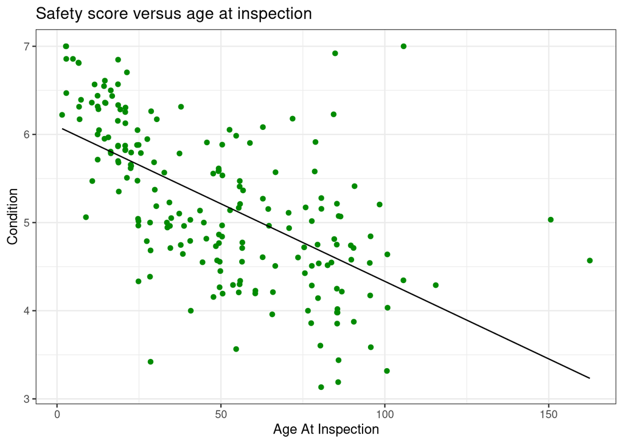

```r
ggplot(data = tcb, aes(x = AgeAtInspection, y = Condition)) +
  geom_point(color = "green4") +
  theme_bw() +
  labs(x = "Age At Inspection", title = "Safety score versus age at inspection") +
  geom_smooth(method = "lm", se = FALSE, color = "black", size = 0.5)
```

```r
tcb %>%
  summarize(xbar = mean(AgeAtInspection),
            sx = sd(AgeAtInspection),
            ybar = mean(Condition),
            sy = sd(Condition),
            r = cor(AgeAtInspection, Condition),
            b1 = r*sy/sx,
            b0 = ybar - b1*xbar)
```

```
      xbar       sx     ybar        sy         r         b1       b0
1 48.97228 30.59651 5.231113 0.8839666 -0.609039 -0.0175958 6.092819
```

```r
# or
mod_tcb <- lm(Condition ~ AgeAtInspection, data = tcb)
summary(mod_tcb)
```

```
Call:
lm(formula = Condition ~ AgeAtInspection, data = tcb)

Residuals:
     Min       1Q   Median       3Q      Max
-2.16969 -0.50561  0.06571  0.43160  2.76761

Coefficients:
                 Estimate Std. Error t value Pr(>|t|)
(Intercept)      6.092819   0.095177   64.02   <2e-16 ***
AgeAtInspection -0.017596   0.001649  -10.67   <2e-16 ***
---
Signif. codes:  0 '***' 0.001 '**' 0.01 '*' 0.05 '.' 0.1 ' ' 1

Residual standard error: 0.7029 on 193 degrees of freedom
Multiple R-squared:  0.3709,    Adjusted R-squared:  0.3677
F-statistic: 113.8 on 1 and 193 DF,  p-value: < 2.2e-16
```

```r
mod_tcb$coefficients
```

```
    (Intercept) AgeAtInspection
      6.0928193      -0.0175958
```

```r
# Take 1000 random samples of size 195
set.seed(3)
n <- 1000
b1 <- numeric(n)
for(i in 1:n){
DF <- sample_n(nyb, size = 195, replace = FALSE)
mod <- lm(Condition ~ AgeAtInspection, data = DF)
b1[i] <- mod$coefficients[2]
}
ep <- quantile(b1, probs = c(0.025, 0.975))
ep
```

```
       2.5%       97.5%
-0.02231104 -0.01409361
```

Note: 95% of the $b_1$ values are between -0.0223 and -0.0141.

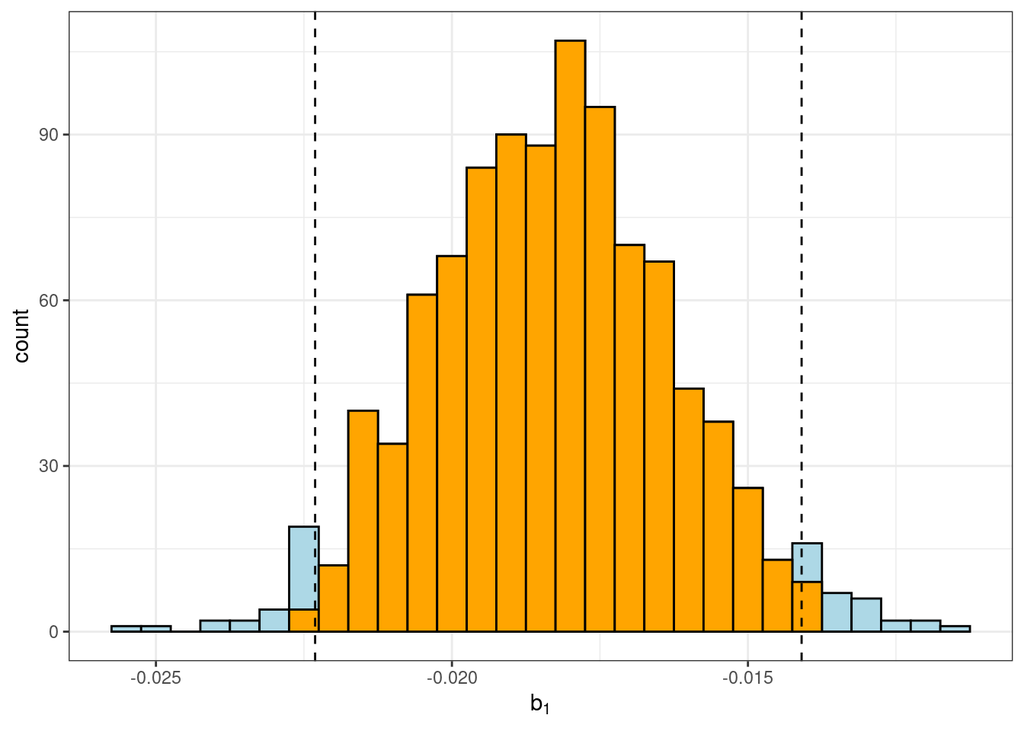

```r
data1 = data.frame(b1 = b1) # create data frame to use with ggplot
ggplot(data = data1, aes(x = b1)) +
  geom_histogram(binwidth = 0.0005, fill = "lightblue", color = "black") +
  geom_histogram(data = subset(data1, b1 > ep[1] & b1 < ep[2]), binwidth = 0.0005,
   color = "black", fill = "orange") +
  theme_bw() +
  geom_vline(xintercept = ep, lty = "dashed") +
  labs(x = expression(b[1]))
```

## 1.2 Burger King

Read in the `Burger_King_Items.csv` data set and store the result in `bki`. Examine the values in `bki`.

```r
# Your Code Goes HERE
```

Create a scatter plot of Fat versus Protein.

```r
# Your Code Goes HERE
```

Compute the least squares estimates and write the equation of the least squares line. Store the result of the `lm` object in `mod_bk`.

```r
# Your Code Goes HERE
```

## 1.3 $R^2$ — The Variation accounted for by the Model

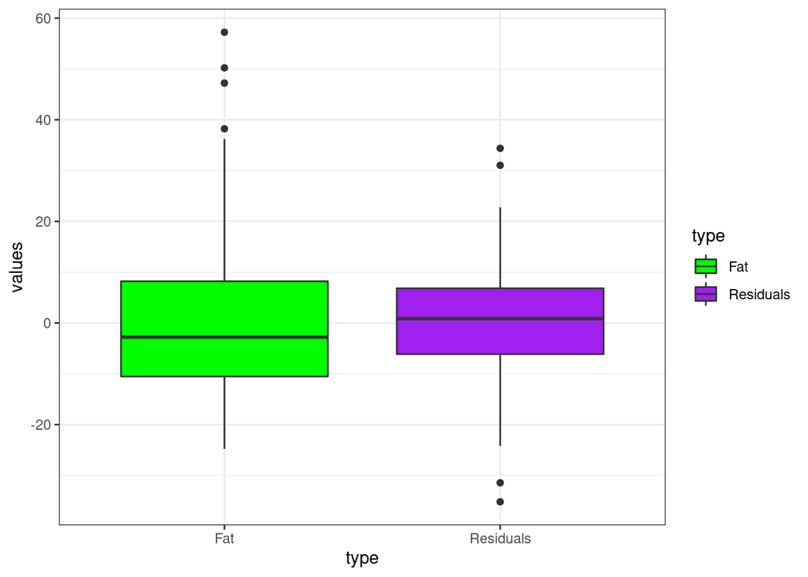

```r
e <- residuals(mod_bk)
fat <- bki$Fat.g. - mean(bki$Fat.g.)
values <- c(e, fat)
type <- rep(c("Residuals", "Fat"), each = 122)
NDF <- data.frame(type = type, values = values)
ggplot(data = NDF, aes(x = type, y = values, fill = type)) +
  geom_boxplot() +
  theme_bw() +
  scale_fill_manual(values = c("green", "purple"))
```

```r
1 - var(e)/var(fat)
```

```
[1] 0.5742613
```

# 2 Step-By-Step Example

Read in the `Cereals.csv` data set and store the data in `Cereals`. Examine the values in `Cereals`.

```r
# Your Code Goes HERE
```

Find the least squares estimates $b_0$ and $b_1$ from regressing `calories` on `sugars`.

```r
# Your Code Goes HERE
```

Write the least squares regression equation for regressing `calories` onto `sugars`.

Create a residuals versus fitted calories plot.

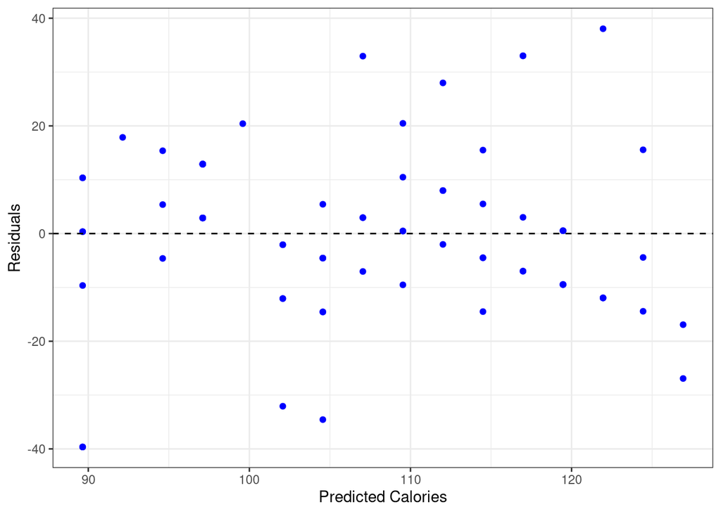

```r
mod_cereal <- lm(calories ~ sugars, data = Cereals)
library(broom)
NS <- augment(mod_cereal)
ggplot(data = NS, aes(x = .fitted, y = .resid)) +
  geom_point(color = "blue") +
  theme_bw() +
  labs(x = "Predicted Calories", y = "Residuals") +
  geom_hline(yintercept = 0, lty = "dashed")
```

# 3 Question # 4 - Homework

```r
library(readxl)
chap07ques04 <- read_xlsx("chap07ques04.xlsx")
knitr::kable(chap07ques04)
```

| Number_of_Sales_People_Working | Sales_(in_$1000) |
| --- | --- |
| 2 | 10 |
| 4 | 12 |
| 7 | 14 |
| 10 | 15 |
| 11 | 18 |
| 11 | 20 |
| 13 | 20 |
| 16 | 22 |
| 17 | 22 |
| 21 | 27 |

```r
mod_lm <- lm(`Sales_(in_$1000)` ~ `Number_of_Sales_People_Working`, data = chap07ques04)
summary(mod_lm)
```

```
Call:
lm(formula = `Sales_(in_$1000)` ~ Number_of_Sales_People_Working,
    data = chap07ques04)

Residuals:
     Min       1Q   Median       3Q      Max
-1.95635 -0.30408  0.08761  0.39137  2.17394

Coefficients:
                               Estimate Std. Error t value Pr(>|t|)
(Intercept)                     8.25931    0.80479   10.26 6.99e-06 ***
Number_of_Sales_People_Working  0.86970    0.06431   13.52 8.58e-07 ***
---
Signif. codes:  0 '***' 0.001 '**' 0.01 '*' 0.05 '.' 0.1 ' ' 1

Residual standard error: 1.135 on 8 degrees of freedom
Multiple R-squared:  0.9581,    Adjusted R-squared:  0.9529
F-statistic: 182.9 on 1 and 8 DF,  p-value: 8.582e-07
```

```r
predict(mod_lm, newdata = data.frame(`Number_of_Sales_People_Working` = 18))
```

```
       1
23.91399
```